# Exploratory Data Analysis

NHANES Survey 2003-2004 Iron Biomarkers in Children 3-5 y

Shannon Haymond, PhD

Report Date: 2020-01-29 14:28:11

## Introduction

This report describes a basic exploratory data analysis of laboratory data from the 2003-2004 NHANES Survey measurements of iron status in children aged 3-5 years old.

[NHANES 2003-2004 Laboratory Data Page](https://wwwn.cdc.gov/nchs/nhanes/Search/DataPage.aspx?Component=Laboratory&CycleBeginYear=2003)

## Summary Statistics

### Statistical summary of factor variables

| skim_variable | n_missing | complete_rate | ordered | n_unique | top_counts |
| --- | --- | --- | --- | --- | --- |
| subject | 0 | 1 | FALSE | 295 | 210: 1, 211: 1, 211: 1, 212: 1 |
| gender | 0 | 1 | FALSE | 2 | Mal: 151, Fem: 144 |
| race_ethn | 0 | 1 | FALSE | 5 | Non: 103, Non: 79, Mex: 74, Oth: 21 |

There are 3 categorical (factor) variables in this dataset representing subject ID, gender, and race/ethnicity. There are 295 unique cases with no missing data for these variables.

### Statistical summary of numeric variables

| skim_variable | n_missing | complete_rate | mean | sd | p0 | p25 | p50 | p75 | p100 | hist |
| --- | --- | --- | --- | --- | --- | --- | --- | --- | --- | --- |
| age_months | 0 | 1 | 48.32 | 7.20 | 36.0 | 42.0 | 48.0 | 55.00 | 60.0 | ▆▇▇▇▇ |
| ft_ngd_l | 0 | 1 | 31.27 | 18.66 | 5.0 | 19.0 | 27.0 | 38.00 | 148.0 | ▇▃▁▁▁ |
| hgb_gd_l | 0 | 1 | 12.70 | 0.77 | 10.6 | 12.2 | 12.6 | 13.15 | 15.0 | ▁▅▇▃▁ |
| mcv_f_l | 0 | 1 | 82.37 | 4.06 | 63.7 | 79.8 | 82.9 | 85.05 | 91.2 | ▁▁▅▇▃ |
| fe_ugd_l | 0 | 1 | 76.00 | 33.83 | 11.0 | 53.0 | 73.0 | 95.00 | 288.0 | ▇▇▁▁▁ |
| tibc_ugd_l | 0 | 1 | 354.37 | 39.35 | 263.0 | 328.0 | 352.0 | 378.50 | 498.0 | ▂▇▅▂▁ |
| tf_sat_pct | 0 | 1 | 21.68 | 9.70 | 3.0 | 14.9 | 20.2 | 27.65 | 71.3 | ▆▇▂▁▁ |

There are 7 numeric variables, representing subject age (in months) and several laboratory measurements related to iron status. There are no missing data for these variables. Ferritin, iron, and transferrin saturation are skewed to the right. Mean and standard deviations are shown in the Table above. The mean age for all subjects is 48 months.

## Visual Data Exploration

### Box Plots by Gender and Race/Ethnicity

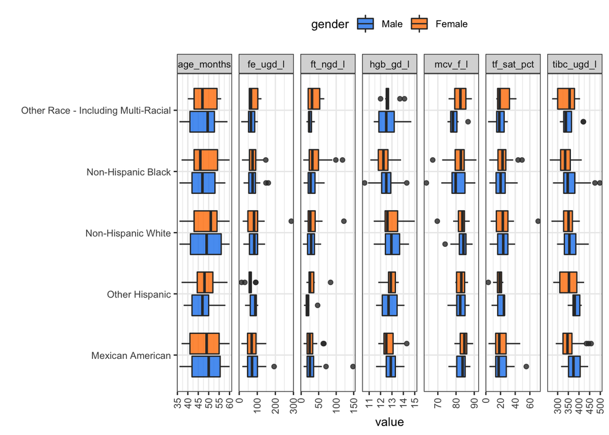

The box plots show little difference in values by gender or by race_ethnicity. There are outliers present in the data that will need to be addressed.

### Bar Plots of Race/Ethnicity by Gender

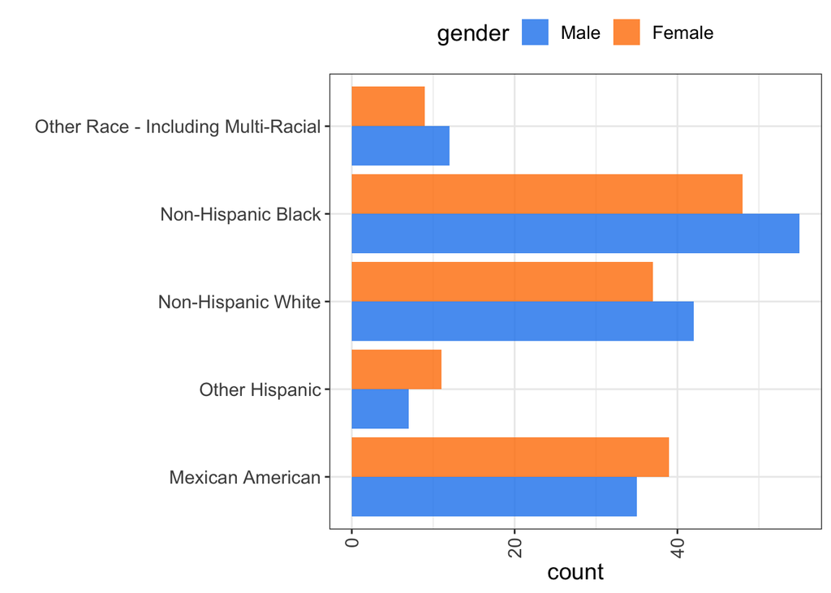

The representation gender is reasonably balanced across all race/ethnicity categories. The ‘Other’ categories have the fewest subjects.

### Correlation Plot for Numeric Variables

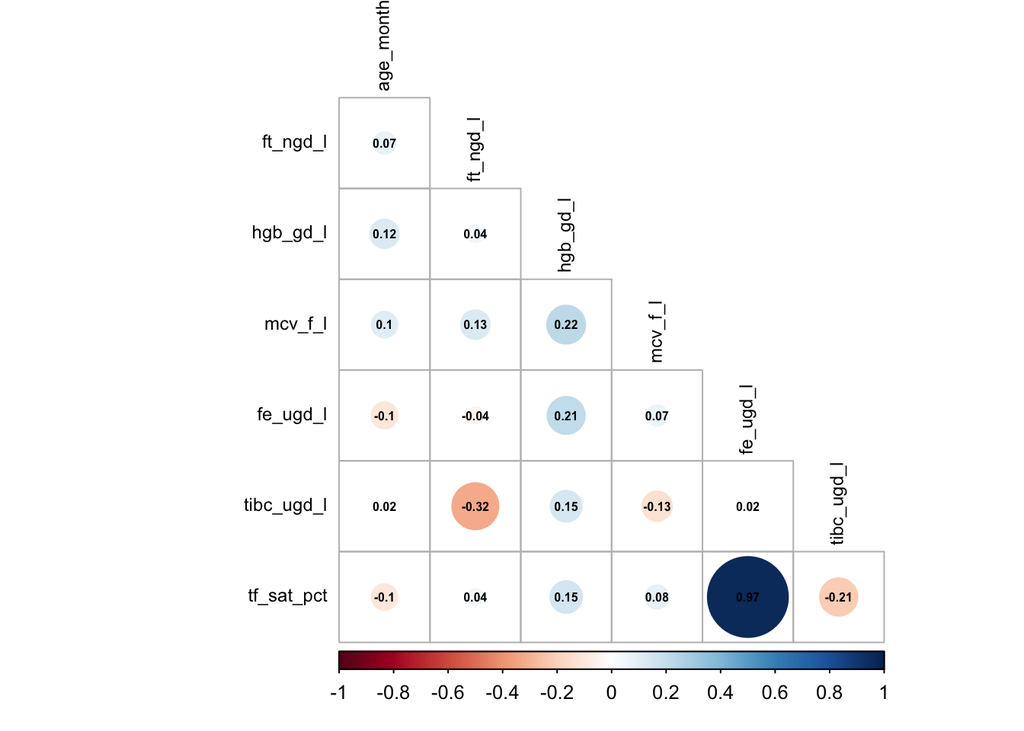